# Risk Factor Analysis

## Outcome Variable

**Outcome Variable:** sstunted

## Predictor Variables

**Intervention Variable:** perdiar6

**Adjustment Set:**

unadjusted

## Stratifying Variables

The analysis was stratified on these variable(s):

- agecat
- studyid
- country

## Data Summary

| agecat | studyid | country | perdiar6 | sstunted | n_cell | n |
| --- | --- | --- | --- | --- | --- | --- |
| Birth | ki0047075b-MAL-ED | BANGLADESH | (0%, 5%] | 0 | 93 | 257 |
| Birth | ki0047075b-MAL-ED | BANGLADESH | (0%, 5%] | 1 | 3 | 257 |
| Birth | ki0047075b-MAL-ED | BANGLADESH | 0% | 0 | 83 | 257 |
| Birth | ki0047075b-MAL-ED | BANGLADESH | 0% | 1 | 3 | 257 |
| Birth | ki0047075b-MAL-ED | BANGLADESH | >5% | 0 | 72 | 257 |
| Birth | ki0047075b-MAL-ED | BANGLADESH | >5% | 1 | 3 | 257 |
| Birth | ki0047075b-MAL-ED | BRAZIL | (0%, 5%] | 0 | 12 | 191 |
| Birth | ki0047075b-MAL-ED | BRAZIL | (0%, 5%] | 1 | 1 | 191 |
| Birth | ki0047075b-MAL-ED | BRAZIL | 0% | 0 | 169 | 191 |
| Birth | ki0047075b-MAL-ED | BRAZIL | 0% | 1 | 7 | 191 |
| Birth | ki0047075b-MAL-ED | BRAZIL | >5% | 0 | 2 | 191 |
| Birth | ki0047075b-MAL-ED | BRAZIL | >5% | 1 | 0 | 191 |
| Birth | ki0047075b-MAL-ED | INDIA | (0%, 5%] | 0 | 105 | 206 |
| Birth | ki0047075b-MAL-ED | INDIA | (0%, 5%] | 1 | 4 | 206 |
| Birth | ki0047075b-MAL-ED | INDIA | 0% | 0 | 44 | 206 |
| Birth | ki0047075b-MAL-ED | INDIA | 0% | 1 | 3 | 206 |
| Birth | ki0047075b-MAL-ED | INDIA | >5% | 0 | 50 | 206 |
| Birth | ki0047075b-MAL-ED | INDIA | >5% | 1 | 0 | 206 |
| Birth | ki0047075b-MAL-ED | NEPAL | (0%, 5%] | 0 | 55 | 173 |
| Birth | ki0047075b-MAL-ED | NEPAL | (0%, 5%] | 1 | 2 | 173 |
| Birth | ki0047075b-MAL-ED | NEPAL | 0% | 0 | 57 | 173 |
| Birth | ki0047075b-MAL-ED | NEPAL | 0% | 1 | 3 | 173 |
| Birth | ki0047075b-MAL-ED | NEPAL | >5% | 0 | 55 | 173 |
| Birth | ki0047075b-MAL-ED | NEPAL | >5% | 1 | 1 | 173 |
| Birth | ki0047075b-MAL-ED | PERU | (0%, 5%] | 0 | 84 | 287 |
| Birth | ki0047075b-MAL-ED | PERU | (0%, 5%] | 1 | 4 | 287 |
| Birth | ki0047075b-MAL-ED | PERU | 0% | 0 | 81 | 287 |
| Birth | ki0047075b-MAL-ED | PERU | 0% | 1 | 2 | 287 |
| Birth | ki0047075b-MAL-ED | PERU | >5% | 0 | 114 | 287 |
| Birth | ki0047075b-MAL-ED | PERU | >5% | 1 | 2 | 287 |

[output cut: 234 more lines]

The following strata were considered:

- agecat: 24 months, studyid: ki0047075b-MAL-ED, country: BANGLADESH
- agecat: 24 months, studyid: ki0047075b-MAL-ED, country: BRAZIL
- agecat: 24 months, studyid: ki0047075b-MAL-ED, country: INDIA
- agecat: 24 months, studyid: ki0047075b-MAL-ED, country: NEPAL
- agecat: 24 months, studyid: ki0047075b-MAL-ED, country: PERU
- agecat: 24 months, studyid: ki0047075b-MAL-ED, country: SOUTH AFRICA
- agecat: 24 months, studyid: ki0047075b-MAL-ED, country: TANZANIA, UNITED REPUBLIC OF
- agecat: 24 months, studyid: ki1017093-NIH-Birth, country: BANGLADESH
- agecat: 24 months, studyid: ki1017093b-PROVIDE, country: BANGLADESH
- agecat: 24 months, studyid: ki1017093c-NIH-Crypto, country: BANGLADESH
- agecat: 24 months, studyid: ki1114097-CMIN, country: BANGLADESH
- agecat: 24 months, studyid: ki1114097-CMIN, country: GUINEA-BISSAU
- agecat: 24 months, studyid: ki1114097-CMIN, country: PERU
- agecat: 24 months, studyid: ki1114097-CONTENT, country: PERU
- agecat: 6 months, studyid: ki0047075b-MAL-ED, country: BANGLADESH
- agecat: 6 months, studyid: ki0047075b-MAL-ED, country: BRAZIL
- agecat: 6 months, studyid: ki0047075b-MAL-ED, country: INDIA
- agecat: 6 months, studyid: ki0047075b-MAL-ED, country: NEPAL
- agecat: 6 months, studyid: ki0047075b-MAL-ED, country: PERU
- agecat: 6 months, studyid: ki0047075b-MAL-ED, country: SOUTH AFRICA
- agecat: 6 months, studyid: ki0047075b-MAL-ED, country: TANZANIA, UNITED REPUBLIC OF
- agecat: 6 months, studyid: ki1000109-ResPak, country: PAKISTAN
- agecat: 6 months, studyid: ki1017093-NIH-Birth, country: BANGLADESH
- agecat: 6 months, studyid: ki1017093b-PROVIDE, country: BANGLADESH
- agecat: 6 months, studyid: ki1017093c-NIH-Crypto, country: BANGLADESH
- agecat: 6 months, studyid: ki1114097-CMIN, country: BANGLADESH
- agecat: 6 months, studyid: ki1114097-CMIN, country: BRAZIL
- agecat: 6 months, studyid: ki1114097-CMIN, country: GUINEA-BISSAU
- agecat: 6 months, studyid: ki1114097-CMIN, country: PERU
- agecat: 6 months, studyid: ki1114097-CONTENT, country: PERU
- agecat: Birth, studyid: ki0047075b-MAL-ED, country: BANGLADESH
- agecat: Birth, studyid: ki0047075b-MAL-ED, country: BRAZIL
- agecat: Birth, studyid: ki0047075b-MAL-ED, country: INDIA
- agecat: Birth, studyid: ki0047075b-MAL-ED, country: NEPAL
- agecat: Birth, studyid: ki0047075b-MAL-ED, country: PERU
- agecat: Birth, studyid: ki0047075b-MAL-ED, country: SOUTH AFRICA
- agecat: Birth, studyid: ki0047075b-MAL-ED, country: TANZANIA, UNITED REPUBLIC OF
- agecat: Birth, studyid: ki1000109-ResPak, country: PAKISTAN
- agecat: Birth, studyid: ki1017093-NIH-Birth, country: BANGLADESH
- agecat: Birth, studyid: ki1017093c-NIH-Crypto, country: BANGLADESH
- agecat: Birth, studyid: ki1114097-CMIN, country: BANGLADESH
- agecat: Birth, studyid: ki1114097-CMIN, country: BRAZIL
- agecat: Birth, studyid: ki1114097-CMIN, country: PERU
- agecat: Birth, studyid: ki1114097-CONTENT, country: PERU

### Dropped Strata

Some strata were dropped due to rare outcomes:

- agecat: Birth, studyid: ki0047075b-MAL-ED, country: BANGLADESH
- agecat: Birth, studyid: ki0047075b-MAL-ED, country: BRAZIL
- agecat: Birth, studyid: ki0047075b-MAL-ED, country: INDIA
- agecat: Birth, studyid: ki0047075b-MAL-ED, country: NEPAL
- agecat: Birth, studyid: ki0047075b-MAL-ED, country: PERU
- agecat: Birth, studyid: ki0047075b-MAL-ED, country: SOUTH AFRICA
- agecat: Birth, studyid: ki0047075b-MAL-ED, country: TANZANIA, UNITED REPUBLIC OF
- agecat: Birth, studyid: ki1000109-ResPak, country: PAKISTAN
- agecat: Birth, studyid: ki1017093-NIH-Birth, country: BANGLADESH
- agecat: Birth, studyid: ki1017093c-NIH-Crypto, country: BANGLADESH
- agecat: Birth, studyid: ki1114097-CMIN, country: BANGLADESH
- agecat: Birth, studyid: ki1114097-CMIN, country: BRAZIL
- agecat: Birth, studyid: ki1114097-CMIN, country: PERU
- agecat: Birth, studyid: ki1114097-CONTENT, country: PERU
- agecat: 6 months, studyid: ki0047075b-MAL-ED, country: BANGLADESH
- agecat: 6 months, studyid: ki0047075b-MAL-ED, country: BRAZIL
- agecat: 6 months, studyid: ki0047075b-MAL-ED, country: INDIA
- agecat: 6 months, studyid: ki0047075b-MAL-ED, country: NEPAL
- agecat: 6 months, studyid: ki0047075b-MAL-ED, country: PERU
- agecat: 6 months, studyid: ki0047075b-MAL-ED, country: SOUTH AFRICA
- agecat: 6 months, studyid: ki0047075b-MAL-ED, country: TANZANIA, UNITED REPUBLIC OF
- agecat: 6 months, studyid: ki1017093b-PROVIDE, country: BANGLADESH
- agecat: 6 months, studyid: ki1114097-CMIN, country: BRAZIL
- agecat: 6 months, studyid: ki1114097-CMIN, country: GUINEA-BISSAU
- agecat: 6 months, studyid: ki1114097-CMIN, country: PERU
- agecat: 6 months, studyid: ki1114097-CONTENT, country: PERU
- agecat: 24 months, studyid: ki0047075b-MAL-ED, country: BRAZIL
- agecat: 24 months, studyid: ki0047075b-MAL-ED, country: NEPAL
- agecat: 24 months, studyid: ki0047075b-MAL-ED, country: PERU
- agecat: 24 months, studyid: ki0047075b-MAL-ED, country: SOUTH AFRICA
- agecat: 24 months, studyid: ki1114097-CMIN, country: GUINEA-BISSAU
- agecat: 24 months, studyid: ki1114097-CMIN, country: PERU
- agecat: 24 months, studyid: ki1114097-CONTENT, country: PERU

## Methods Detail

We’re interested in the causal parameters $E[Y_a]$ for all values of $a \in \mathcal{A}$. These parameters represent the mean outcome if, possibly contrary to fact, we intervened to set all units to have $A=a$. Under the randomization and positivity assumptions, these are identified by the statistical parameters $\psi_a=E_W[E_{Y|A,W}(Y|A=a,W)]$. In addition, we’re interested in the mean of $Y$, $E[Y]$ under no intervention (the observed mean). We will estimate these parameters by using SuperLearner to fit the relevant likelihood factors – $E_{Y|A,W}(Y|A=a,W)$ and $p(A=a|W)$, and then updating our likelihood fit using a joint TMLE.

For unadjusted analyses ($W=\{\}$), initial likelihoods were estimated using Lrnr_glm to estimate the simple $E(Y|A)$ and Lrnr_mean to estimate $p(A)$. For adjusted analyses, a small library containing Lrnr_glmnet, Lrnr_xgboost, and Lrnr_mean was used.

Having estimated these parameters, we will then use the delta method to estimate relative risks and attributable risks relative to a prespecified baseline level of $A$.

# Results Detail

## Results Plots

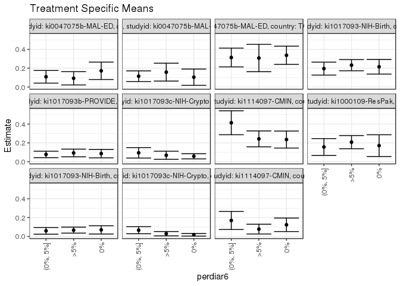

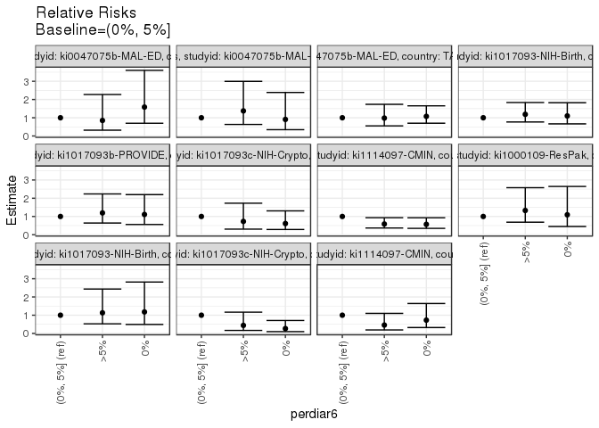

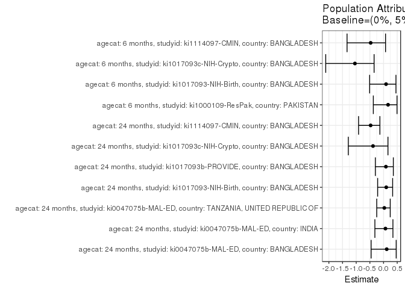

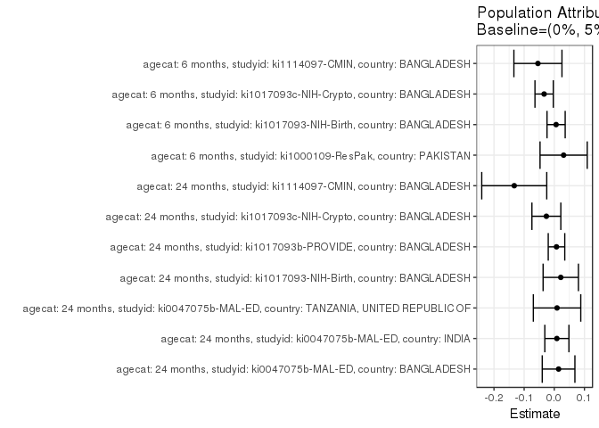

## Results Table

### Parameter: TSM

| agecat | studyid | country | intervention_level | baseline_level | estimate | ci_lower | ci_upper |
| --- | --- | --- | --- | --- | --- | --- | --- |
| 6 months | ki1000109-ResPak | PAKISTAN | (0%, 5%] | NA | 0.1562500 | 0.0671042 | 0.2453958 |
| 6 months | ki1000109-ResPak | PAKISTAN | 0% | NA | 0.1707317 | 0.0553102 | 0.2861532 |
| 6 months | ki1000109-ResPak | PAKISTAN | >5% | NA | 0.2076923 | 0.1378112 | 0.2775734 |
| 6 months | ki1017093-NIH-Birth | BANGLADESH | (0%, 5%] | NA | 0.0591716 | 0.0235657 | 0.0947774 |
| 6 months | ki1017093-NIH-Birth | BANGLADESH | 0% | NA | 0.0697674 | 0.0257647 | 0.1137702 |
| 6 months | ki1017093-NIH-Birth | BANGLADESH | >5% | NA | 0.0669456 | 0.0352303 | 0.0986609 |
| 6 months | ki1017093c-NIH-Crypto | BANGLADESH | (0%, 5%] | NA | 0.0658683 | 0.0282208 | 0.1035157 |
| 6 months | ki1017093c-NIH-Crypto | BANGLADESH | 0% | NA | 0.0175953 | 0.0036310 | 0.0315596 |
| 6 months | ki1017093c-NIH-Crypto | BANGLADESH | >5% | NA | 0.0289855 | 0.0061153 | 0.0518557 |
| 6 months | ki1114097-CMIN | BANGLADESH | (0%, 5%] | NA | 0.1694915 | 0.0735595 | 0.2654235 |
| 6 months | ki1114097-CMIN | BANGLADESH | 0% | NA | 0.1234568 | 0.0516699 | 0.1952437 |
| 6 months | ki1114097-CMIN | BANGLADESH | >5% | NA | 0.0776699 | 0.0258741 | 0.1294657 |
| 24 months | ki0047075b-MAL-ED | BANGLADESH | (0%, 5%] | NA | 0.1084337 | 0.0413844 | 0.1754831 |
| 24 months | ki0047075b-MAL-ED | BANGLADESH | 0% | NA | 0.1718750 | 0.0792263 | 0.2645237 |
| 24 months | ki0047075b-MAL-ED | BANGLADESH | >5% | NA | 0.0923077 | 0.0217724 | 0.1628430 |
| 24 months | ki0047075b-MAL-ED | INDIA | (0%, 5%] | NA | 0.1147541 | 0.0580724 | 0.1714358 |
| 24 months | ki0047075b-MAL-ED | INDIA | 0% | NA | 0.1041667 | 0.0175574 | 0.1907759 |
| 24 months | ki0047075b-MAL-ED | INDIA | >5% | NA | 0.1578947 | 0.0630231 | 0.2527664 |
| 24 months | ki0047075b-MAL-ED | TANZANIA, UNITED REPUBLIC OF | (0%, 5%] | NA | 0.3132530 | 0.2132364 | 0.4132696 |
| 24 months | ki0047075b-MAL-ED | TANZANIA, UNITED REPUBLIC OF | 0% | NA | 0.3369565 | 0.2401445 | 0.4337685 |
| 24 months | ki0047075b-MAL-ED | TANZANIA, UNITED REPUBLIC OF | >5% | NA | 0.3076923 | 0.1625009 | 0.4528837 |
| 24 months | ki1017093-NIH-Birth | BANGLADESH | (0%, 5%] | NA | 0.1953125 | 0.1265537 | 0.2640713 |
| 24 months | ki1017093-NIH-Birth | BANGLADESH | 0% | NA | 0.2149533 | 0.1370272 | 0.2928793 |
| 24 months | ki1017093-NIH-Birth | BANGLADESH | >5% | NA | 0.2319588 | 0.1724951 | 0.2914224 |
| 24 months | ki1017093b-PROVIDE | BANGLADESH | (0%, 5%] | NA | 0.0775862 | 0.0431325 | 0.1120399 |
| 24 months | ki1017093b-PROVIDE | BANGLADESH | 0% | NA | 0.0860927 | 0.0413141 | 0.1308713 |
| 24 months | ki1017093b-PROVIDE | BANGLADESH | >5% | NA | 0.0927835 | 0.0519220 | 0.1336450 |
| 24 months | ki1017093c-NIH-Crypto | BANGLADESH | (0%, 5%] | NA | 0.0943396 | 0.0386406 | 0.1500387 |
| 24 months | ki1017093c-NIH-Crypto | BANGLADESH | 0% | NA | 0.0577617 | 0.0302618 | 0.0852617 |
| 24 months | ki1017093c-NIH-Crypto | BANGLADESH | >5% | NA | 0.0687023 | 0.0253447 | 0.1120599 |
| 24 months | ki1114097-CMIN | BANGLADESH | (0%, 5%] | NA | 0.4137931 | 0.2867795 | 0.5408067 |
| 24 months | ki1114097-CMIN | BANGLADESH | 0% | NA | 0.2352941 | 0.1449311 | 0.3256571 |
| 24 months | ki1114097-CMIN | BANGLADESH | >5% | NA | 0.2424242 | 0.1578320 | 0.3270165 |

### Parameter: E(Y)

| agecat | studyid | country | intervention_level | baseline_level | estimate | ci_lower | ci_upper |
| --- | --- | --- | --- | --- | --- | --- | --- |
| 6 months | ki1000109-ResPak | PAKISTAN | NA | NA | 0.1872340 | 0.1372518 | 0.2372162 |
| 6 months | ki1017093-NIH-Birth | BANGLADESH | NA | NA | 0.0651769 | 0.0442802 | 0.0860736 |
| 6 months | ki1017093c-NIH-Crypto | BANGLADESH | NA | NA | 0.0321678 | 0.0192256 | 0.0451101 |
| 6 months | ki1114097-CMIN | BANGLADESH | NA | NA | 0.1152263 | 0.0749980 | 0.1554547 |
| 24 months | ki0047075b-MAL-ED | BANGLADESH | NA | NA | 0.1226415 | 0.0783812 | 0.1669018 |
| 24 months | ki0047075b-MAL-ED | INDIA | NA | NA | 0.1233480 | 0.0804760 | 0.1662200 |
| 24 months | ki0047075b-MAL-ED | TANZANIA, UNITED REPUBLIC OF | NA | NA | 0.3224299 | 0.2596598 | 0.3852000 |
| 24 months | ki1017093-NIH-Birth | BANGLADESH | NA | NA | 0.2167832 | 0.1777459 | 0.2558205 |
| 24 months | ki1017093b-PROVIDE | BANGLADESH | NA | NA | 0.0849220 | 0.0621566 | 0.1076874 |
| 24 months | ki1017093c-NIH-Crypto | BANGLADESH | NA | NA | 0.0680934 | 0.0462948 | 0.0898920 |
| 24 months | ki1114097-CMIN | BANGLADESH | NA | NA | 0.2809917 | 0.2242434 | 0.3377401 |

### Parameter: RR

| agecat | studyid | country | intervention_level | baseline_level | estimate | ci_lower | ci_upper |
| --- | --- | --- | --- | --- | --- | --- | --- |
| 6 months | ki1000109-ResPak | PAKISTAN | (0%, 5%] | (0%, 5%] | 1.0000000 | 1.0000000 | 1.0000000 |
| 6 months | ki1000109-ResPak | PAKISTAN | 0% | (0%, 5%] | 1.0926829 | 0.4511406 | 2.6465272 |
| 6 months | ki1000109-ResPak | PAKISTAN | >5% | (0%, 5%] | 1.3292308 | 0.6853974 | 2.5778538 |
| 6 months | ki1017093-NIH-Birth | BANGLADESH | (0%, 5%] | (0%, 5%] | 1.0000000 | 1.0000000 | 1.0000000 |
| 6 months | ki1017093-NIH-Birth | BANGLADESH | 0% | (0%, 5%] | 1.1790698 | 0.4931285 | 2.8191544 |
| 6 months | ki1017093-NIH-Birth | BANGLADESH | >5% | (0%, 5%] | 1.1313808 | 0.5260227 | 2.4333976 |
| 6 months | ki1017093c-NIH-Crypto | BANGLADESH | (0%, 5%] | (0%, 5%] | 1.0000000 | 1.0000000 | 1.0000000 |
| 6 months | ki1017093c-NIH-Crypto | BANGLADESH | 0% | (0%, 5%] | 0.2671288 | 0.1004544 | 0.7103499 |
| 6 months | ki1017093c-NIH-Crypto | BANGLADESH | >5% | (0%, 5%] | 0.4400527 | 0.1661030 | 1.1658209 |
| 6 months | ki1114097-CMIN | BANGLADESH | (0%, 5%] | (0%, 5%] | 1.0000000 | 1.0000000 | 1.0000000 |
| 6 months | ki1114097-CMIN | BANGLADESH | 0% | (0%, 5%] | 0.7283951 | 0.3235598 | 1.6397567 |
| 6 months | ki1114097-CMIN | BANGLADESH | >5% | (0%, 5%] | 0.4582524 | 0.1910885 | 1.0989427 |
| 24 months | ki0047075b-MAL-ED | BANGLADESH | (0%, 5%] | (0%, 5%] | 1.0000000 | 1.0000000 | 1.0000000 |
| 24 months | ki0047075b-MAL-ED | BANGLADESH | 0% | (0%, 5%] | 1.5850694 | 0.6978931 | 3.6000432 |
| 24 months | ki0047075b-MAL-ED | BANGLADESH | >5% | (0%, 5%] | 0.8512821 | 0.3185453 | 2.2749708 |
| 24 months | ki0047075b-MAL-ED | INDIA | (0%, 5%] | (0%, 5%] | 1.0000000 | 1.0000000 | 1.0000000 |
| 24 months | ki0047075b-MAL-ED | INDIA | 0% | (0%, 5%] | 0.9077381 | 0.3451072 | 2.3876306 |
| 24 months | ki0047075b-MAL-ED | INDIA | >5% | (0%, 5%] | 1.3759398 | 0.6321162 | 2.9950355 |
| 24 months | ki0047075b-MAL-ED | TANZANIA, UNITED REPUBLIC OF | (0%, 5%] | (0%, 5%] | 1.0000000 | 1.0000000 | 1.0000000 |
| 24 months | ki0047075b-MAL-ED | TANZANIA, UNITED REPUBLIC OF | 0% | (0%, 5%] | 1.0756689 | 0.7000655 | 1.6527933 |
| 24 months | ki0047075b-MAL-ED | TANZANIA, UNITED REPUBLIC OF | >5% | (0%, 5%] | 0.9822485 | 0.5556302 | 1.7364286 |
| 24 months | ki1017093-NIH-Birth | BANGLADESH | (0%, 5%] | (0%, 5%] | 1.0000000 | 1.0000000 | 1.0000000 |
| 24 months | ki1017093-NIH-Birth | BANGLADESH | 0% | (0%, 5%] | 1.1005607 | 0.6639739 | 1.8242192 |
| 24 months | ki1017093-NIH-Birth | BANGLADESH | >5% | (0%, 5%] | 1.1876289 | 0.7683319 | 1.8357461 |
| 24 months | ki1017093b-PROVIDE | BANGLADESH | (0%, 5%] | (0%, 5%] | 1.0000000 | 1.0000000 | 1.0000000 |
| 24 months | ki1017093b-PROVIDE | BANGLADESH | 0% | (0%, 5%] | 1.1096394 | 0.5599722 | 2.1988586 |
| 24 months | ki1017093b-PROVIDE | BANGLADESH | >5% | (0%, 5%] | 1.1958763 | 0.6398391 | 2.2351245 |
| 24 months | ki1017093c-NIH-Crypto | BANGLADESH | (0%, 5%] | (0%, 5%] | 1.0000000 | 1.0000000 | 1.0000000 |
| 24 months | ki1017093c-NIH-Crypto | BANGLADESH | 0% | (0%, 5%] | 0.6122744 | 0.2867840 | 1.3071854 |
| 24 months | ki1017093c-NIH-Crypto | BANGLADESH | >5% | (0%, 5%] | 0.7282443 | 0.3068699 | 1.7282232 |
| 24 months | ki1114097-CMIN | BANGLADESH | (0%, 5%] | (0%, 5%] | 1.0000000 | 1.0000000 | 1.0000000 |
| 24 months | ki1114097-CMIN | BANGLADESH | 0% | (0%, 5%] | 0.5686275 | 0.3477864 | 0.9297004 |
| 24 months | ki1114097-CMIN | BANGLADESH | >5% | (0%, 5%] | 0.5858586 | 0.3680956 | 0.9324488 |

### Parameter: PAR

| agecat | studyid | country | intervention_level | baseline_level | estimate | ci_lower | ci_upper |
| --- | --- | --- | --- | --- | --- | --- | --- |
| 6 months | ki1000109-ResPak | PAKISTAN | (0%, 5%] | NA | 0.0309840 | -0.0472249 | 0.1091929 |
| 6 months | ki1017093-NIH-Birth | BANGLADESH | (0%, 5%] | NA | 0.0060053 | -0.0241025 | 0.0361131 |
| 6 months | ki1017093c-NIH-Crypto | BANGLADESH | (0%, 5%] | NA | -0.0337004 | -0.0640773 | -0.0033236 |
| 6 months | ki1114097-CMIN | BANGLADESH | (0%, 5%] | NA | -0.0542652 | -0.1339668 | 0.0254364 |
| 24 months | ki0047075b-MAL-ED | BANGLADESH | (0%, 5%] | NA | 0.0142078 | -0.0399627 | 0.0683782 |
| 24 months | ki0047075b-MAL-ED | INDIA | (0%, 5%] | NA | 0.0085939 | -0.0313736 | 0.0485614 |
| 24 months | ki0047075b-MAL-ED | TANZANIA, UNITED REPUBLIC OF | (0%, 5%] | NA | 0.0091769 | -0.0694604 | 0.0878142 |
| 24 months | ki1017093-NIH-Birth | BANGLADESH | (0%, 5%] | NA | 0.0214707 | -0.0370993 | 0.0800408 |
| 24 months | ki1017093b-PROVIDE | BANGLADESH | (0%, 5%] | NA | 0.0073358 | -0.0200638 | 0.0347354 |
| 24 months | ki1017093c-NIH-Crypto | BANGLADESH | (0%, 5%] | NA | -0.0262462 | -0.0741835 | 0.0216910 |
| 24 months | ki1114097-CMIN | BANGLADESH | (0%, 5%] | NA | -0.1328014 | -0.2405971 | -0.0250056 |

### Parameter: PAF

| agecat | studyid | country | intervention_level | baseline_level | estimate | ci_lower | ci_upper |
| --- | --- | --- | --- | --- | --- | --- | --- |
| 6 months | ki1000109-ResPak | PAKISTAN | (0%, 5%] | NA | 0.1654830 | -0.3742511 | 0.4932377 |
| 6 months | ki1017093-NIH-Birth | BANGLADESH | (0%, 5%] | NA | 0.0921386 | -0.5087008 | 0.4536940 |
| 6 months | ki1017093c-NIH-Crypto | BANGLADESH | (0%, 5%] | NA | -1.0476438 | -2.1152367 | -0.3459154 |
| 6 months | ki1114097-CMIN | BANGLADESH | (0%, 5%] | NA | -0.4709443 | -1.3346838 | 0.0732462 |
| 24 months | ki0047075b-MAL-ED | BANGLADESH | (0%, 5%] | NA | 0.1158480 | -0.4546393 | 0.4625989 |
| 24 months | ki0047075b-MAL-ED | INDIA | (0%, 5%] | NA | 0.0696721 | -0.3169930 | 0.3428135 |
| 24 months | ki0047075b-MAL-ED | TANZANIA, UNITED REPUBLIC OF | (0%, 5%] | NA | 0.0284617 | -0.2487650 | 0.2441438 |
| 24 months | ki1017093-NIH-Birth | BANGLADESH | (0%, 5%] | NA | 0.0990423 | -0.2156197 | 0.3322544 |
| 24 months | ki1017093b-PROVIDE | BANGLADESH | (0%, 5%] | NA | 0.0863828 | -0.2995927 | 0.3577246 |
| 24 months | ki1017093c-NIH-Crypto | BANGLADESH | (0%, 5%] | NA | -0.3854447 | -1.2884906 | 0.1612563 |
| 24 months | ki1114097-CMIN | BANGLADESH | (0%, 5%] | NA | -0.4726166 | -0.9131709 | -0.1335107 |